# ESR SST rolling average plots

Matt Callahan

7/26/2022

## Overview

This brief describes the creation of time series trend plots in the SST ESR contributions. The figure captions from previous ESRs read “time series trend of SST (seasonality and noise removed) for…” In brief, this analysis starts with daily sst values for each ESR subregion. From daily SST, a new data frame is created with the following fields: * date * observation: the SST value for that date * trend: the average temperature for the year surrounding the date (6 months on either side) * seasonal: The average temperature on that date * random: the remainder of the variation in the observation unexplained by trend and seasonal

The trend, seasonal, and random components sum to the observation for each day.  
observation=trend+seasonal+random.

This analysis is accomplished using the *dts1* function in the ggplottimeseries package https://rdrr.io/github/brisneve/ggplottimeseries/src/R/dts1.R, which in turn uses the base *decompose* function https://rdrr.io/r/stats/decompose.html

## Example

Bering Sea

```r
####load packages and data####
library(tidyverse)
library(httr)
library(lubridate)
```

```r
#devtools::install_github("brisneve/ggplottimeseries")
library(ggplottimeseries)

#load data from AKFIN web service
newdat <- httr::content(httr::GET('https://apex.psmfc.org/akfin/data_marts/akmp/ecosystem_sub_crw_avg_sst?ecosystem_sub=Southeastern%20Bering%20Sea,Northern%20Bering%20Sea&start_date=19850101&end_date=20221231'), type = "application/json") %>%
  bind_rows %>%
  mutate(date=as_date(READ_DATE)) %>%
  data.frame %>%
  dplyr::select(date,meansst=MEANSST,Ecosystem_sub=ECOSYSTEM_SUB) %>%
  mutate(doy=yday(date),
         year=year(date),
         month=month(date),
         day=day(date),
         newdate=as.Date(ifelse(month>=9,as.character(as.Date(paste("1999",month,day,sep="-"),format="%Y-%m-%d")),
                                as.character(as.Date(paste("2000",month,day,sep="-"),format="%Y-%m-%d"))),format("%Y-%m-%d")),
         year2=ifelse(month>=9,year+1,year)) %>%
  arrange(date)
```

```r
####perform time series decomposition####
#This could be combined but is left separate for clarity
df1 <- newdat %>%
  filter(Ecosystem_sub=="Southeastern Bering Sea")

#  Perform the time series decomposition for the EGOA, setting the frequency as 365.25 because we have daily data with leap years.
df1 <- dts1(df1$date,df1$meansst,365.25, type = "additive") %>%
  mutate(Ecosystem_sub="Southeastern Bering Sea",
         year=year(date))

#  Repeat for the wgoa
df2 <- newdat %>%
  filter(Ecosystem_sub=="Northern Bering Sea")

df2 <- dts1(df2$date,df2$meansst,365.25, type = "additive") %>%
  mutate(Ecosystem_sub="Northern Bering Sea",
         year=year(date))

#  Combine the time series decompositions for each area and reorder the factors.
df <- df1 %>%
  bind_rows(df2)

#  Create the horizontal mean and sd lines for the 30 year baseline period.
dfmean <- df %>%
  group_by(Ecosystem_sub) %>%
  summarise(meantrend=mean(trend[between(year,1985,2014)],na.rm=TRUE),
            sdtrend=sd(trend[between(year,1985,2014)],na.rm=TRUE))
```

```r
####explore data####
head(df)
```

```
##         date observation trend  seasonal random           Ecosystem_sub year
## 1 1985-01-01        3.51    NA -2.220132     NA Southeastern Bering Sea 1985
## 2 1985-01-02        3.46    NA -2.280189     NA Southeastern Bering Sea 1985
## 3 1985-01-03        3.32    NA -2.302286     NA Southeastern Bering Sea 1985
## 4 1985-01-04        2.91    NA -2.325927     NA Southeastern Bering Sea 1985
## 5 1985-01-05        2.86    NA -2.374400     NA Southeastern Bering Sea 1985
## 6 1985-01-06        3.41    NA -2.398290     NA Southeastern Bering Sea 1985
```

```r
#trend and random are NA because they are in the earliest six months of the series

##confirm relationship between variables, pick last fourth of july in the SEBS.
with(df%>%filter(date=="2021-07-04" & Ecosystem_sub=="Southeastern Bering Sea"), observation)
```

```
## [1] 7.83
```

```r
#sum others
with(df%>%filter(date=="2021-07-04" & Ecosystem_sub=="Southeastern Bering Sea"), trend+seasonal+random)
```

```
## [1] 7.83
```

```r
##confirm trend is the year around any date
with(df%>%filter(year==1999 & Ecosystem_sub=="Southeastern Bering Sea"), mean(observation))
```

```
## [1] 3.045534
```

```r
with(df%>%filter(date=="1999-07-01" & Ecosystem_sub=="Southeastern Bering Sea"), trend)
```

```
## [1] 3.048816
```

```r
#slightly off, but very close, probably because of the leap year adjustment in the trend calculation.
```

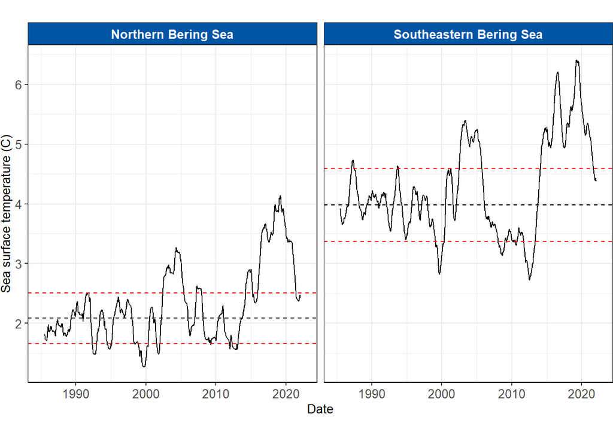

```r
####plot####
OceansBlue2='#0055A4'
df %>%
  #plots trend for each day
  ggplot(aes(x = date, y = trend)) +
  geom_line(color="black") +
  #mean and sd
  geom_hline(data=dfmean,aes(yintercept=meantrend),linetype=2) +
  geom_hline(data=dfmean,aes(yintercept=meantrend+sdtrend),linetype=2,color="red") +
  geom_hline(data=dfmean,aes(yintercept=meantrend-sdtrend),linetype=2,color="red") +
  facet_wrap(~Ecosystem_sub) +
  theme_bw()+
  theme(strip.text = element_text(size=10,color="white",family="sans",face="bold"),
        strip.background = element_rect(fill=OceansBlue2),
        axis.title = element_text(size=10,family="sans"),
        axis.text = element_text(size=10,family="sans"),
        panel.border=element_rect(colour="black",size=0.5, fill=NA),
        plot.margin=unit(c(0.65,0,0.65,0),"cm")) +
  ylab("Sea surface temperature (C)") +
  xlab("Date")
```